# March Madness

Christopher Loyd

2026-03-16

## Premise

With the new age of data taking hold in all facets of sports, it makes sense that one would try to apply it to one of the most unpredictable sporting events of all time. In this project, I attempt to create a statistic that combines the strengths of multiple mainstream statistics used in Men’s College Basketball.

## The Stats

There are four main statistics used in modern college basketball that we will look at in this project: NET Rank, Average Opponent NET Rank, Strength of Schedule, and Wins Above Bubble (WAB).

NET Rank is generated by NCAA themselves to evaluate the overall strength of one team. It is the used by NCAA to determine the rankings throughout the regular season.

The Average Opponent NET Rank is what it says. It takes the average the NET Rank of every opponent one team has on their schedule.

Strength of Schedule is like Average Opponent NET Rank but goes more in depth in determining the quality of opponents a team has in one season.

Wins Above Bubble is a newer statistic that determines how many more wins a team would have over the last team that gets into the tournament if the team played the same schedule as the person. More will be said about this stat later.

## Analysis I

### Sample Space

This study goes over the results of the 2022-2025 NCAA Playoff brackets. Each tournament saw a variety of overal results with 2022 and 2023 including many upsets and 2025 having all 1 seeds making it to the Final Four.

### Method 1

The first method of testing is cut and dry. Every team in each bracket was listed from first to last in their respective statistic. In each match up, the team ranking higher would be predicted to move on.

### Method 2

To account for closer match ups, the second method had it so if two teams where within 5 of each other in the rankings then the team ranked lower would be picked.

### First Results

By listing all of the match ups in each year and then assigning a 1 for a correct prediction and a 0 for an incorrect prediction, I took the sum of the column to determine the correct amount of predictions for each statistic for each method. The following table is the result.

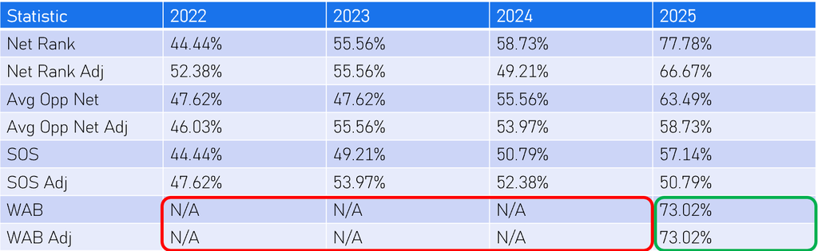

Table 1

Notice the gap in the table. WAB was not used as a general statistic for college basketball under the 2025 tournament. With it being so accurate for the only year it was used, it may be fruitful to determine WAB for the prior years.

## Wins Above Bubble

WAB predicts how many wins a bubble team would have with your schedule and then takes the difference of the wins you had and the wins a bubble team would have. For that simulation we have to use the Pythagorean Expectation formula developed by Bill James to find a team’s Average Win Percentage.

$$\begin{aligned}
\frac{(\text{runs scored})^2}{(\text{runs scored})^2+(\text{runs
allowed})^2}
\end{aligned}$$

We will change the exponent in this formula from 2 to 10 for better prediction in college basketball. For “runs scored” we will be using the offensive rating attributed to the team on KenPom and for “runs allowed” we will be using the defensive rating.

This will be applied to every team from the 2022-2024 seasons, not just tournament teams but every Division I team. Once that is done, then we can simulate how a bubble team would fare having the schedule of a certain tournament team. For this we will need to employ another Bill James formula of Log5.

$$\begin{aligned}
P_{A,B} = \frac{P_A - P_AP_B}{P_A + P_B - 2P_AP_B}
\end{aligned}$$

For every $P_A$ we will be using the average win percentage of a bubble team from the year we are calculating. The result of the Log5 function will give us chance that the bubble team will win against a team on the schedule. If the tournament team won that game, then subtracting that chance from 1 will yield the wins that the tournament team made above the bubble team. If the tournament team lost that game, then chance will be subtracted fully from the aggregate WAB total.

To achieve the quantity of calculation needed to figure out the WAB score for 68 teams over 3 different years, I was able to create a Python script that accepted a list of tuples. The first entry had the name of the team that was played and the second entry had W or L for win or loss. The team name is matched with the name of a team in a dictionary which had a corresponding Average Win Percentage. A for loop was used to subtract the number from 1 if the second entry was a W and take the inverse of the number if the second entry was a L. The result for each game on the schedule was appended to a list which was summed to give the WAB for team.

With that method, the WAB for every tournament team in the 2022-2024 season was created, allowing the table from earlier to be completed.

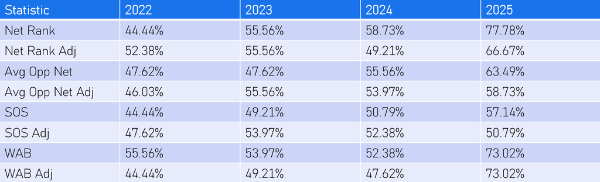

Table 1 Updated

## Weighted Vote Model (Constrained)

Now that the table is completed, we can now make our first attempt in create our “super statistic.” In this attempt, I decided to run a constrained weighted vote model. We assign all 8 methods a weight of 0.125 and then run simulations and have additional weight added to the more accurate methods and take away weight to the less accurate methods.

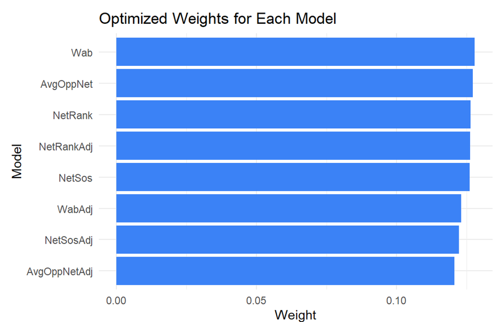

Figure 1

As seen in Figure 1, the results weights have little change. This is due to the initial methods being similar in their overall accuracy as we saw in Table 1. Another factor for the low amount of variability is that the weight model we ran and the constraint of the sum of the weight being less than 1.

I then took the resulting weights and run it in an ensemble model. Hopefully, the ensemble model will be more accurate than any of the methods that it was based on. Let’s see the results.

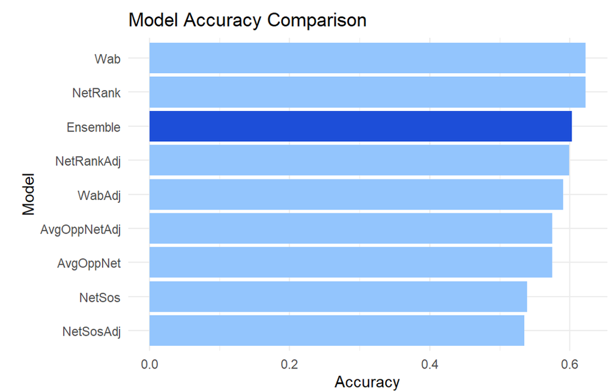

Figure 2

Unfortunately, both NET Rank and WAB were more accurate then our ensemble model based on constrained weighted voting. At this point, a key factor for this could be that the methods that the model were based on were too similar.

I decided to create a correlation matrix to check to see if this was the case.

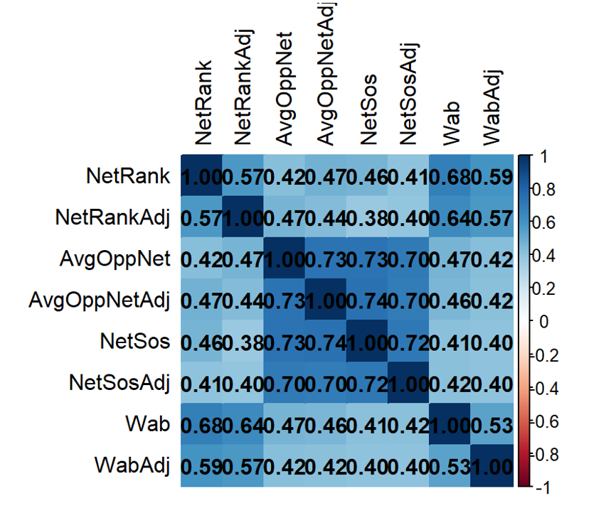

Figure 3

This is good news. Our initial methods are not too similar. Meaning, they predicted the same winner for some match ups but also predicted different winners for other match ups. This means, that our constrained weight model was what was most likely holding us back in creating our super stat.

## Logistical Stacking

Using logistical stacking allows for a more unconstrained approach when assigning weight to each of the 8 methods that we are basing our super stat on. Logistical stacking also uses logistic regression which is more suitable for our project since we are predicting wins or losses.

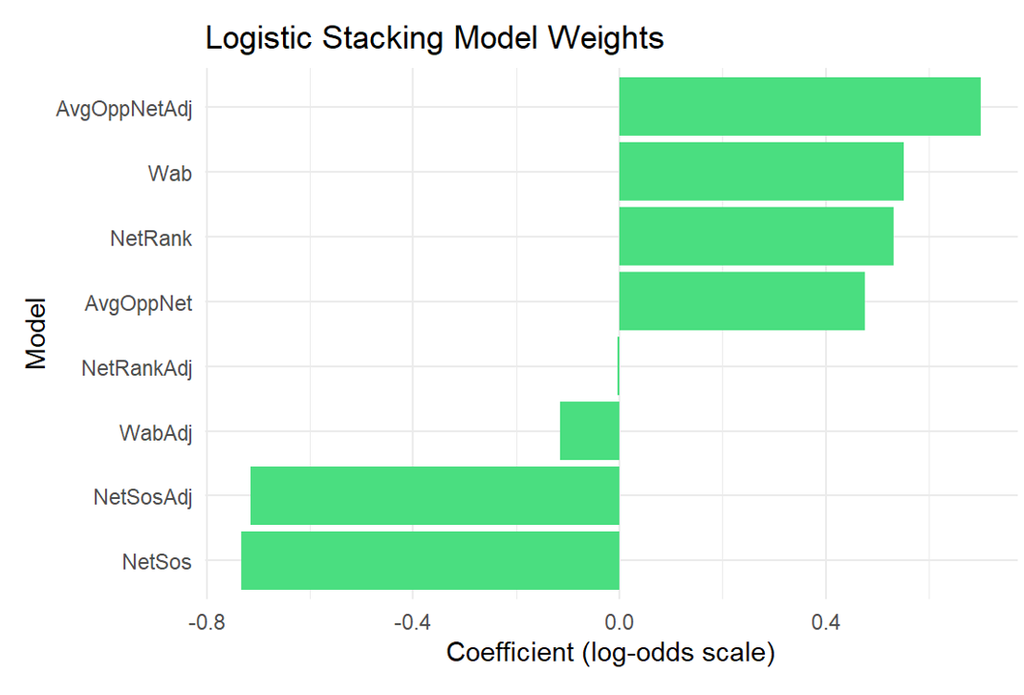

Figure 4

We are already on a better path with the resulting coefficients given via logistical stacking. We can also see that some of our methods were deems less accurate and therefore given a negative coefficient.

Curious to see if significant progress was made, I ran another ensemble model with the coefficients supplied by logistical stacking and compared the accuracy with our first constrained weighted model.

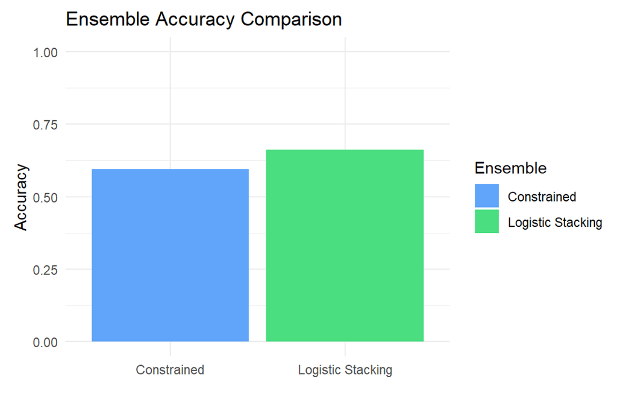

Figure 5

A slight increase has been made! I rushed to check the statistical significance of this progress by running a McNemar’s Chi-squared test in R which yielded…

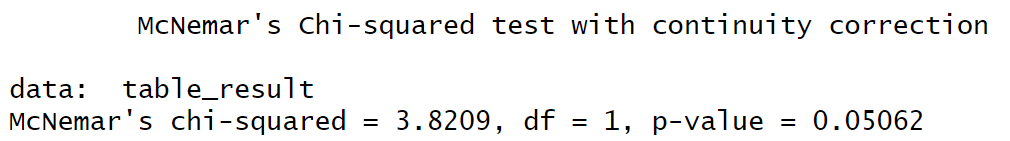

Figure 6

So close! I don’t believe I’ve ever seen a p-value that close to 0.05 before.

## Conclusions

My key takeaways from this project are firstly that logistical stacking, despite not yielding the significance that I was wanting, is a step in the right direction to creating a super statistic. I believe that, given more time to compile more data from prior tournaments, the model could be more properly trained.

I also believe that the inclusion of more statistics, defensive and offensive efficiency, Quad 1 Wins, pace, and 3-point accuracy could make for a more diverse model.

Finally, for future projects, I would love to attempt to create a model that can be more accurate deeper into the tournament. Overall predictability is nice, but if I could reward models that are able to predict the Final Four accurately, that could lend towards an more useful model in trying to fill out my bracket.